# Predict_413_Discussion_3

### 2.3 EST Model AUTO

Our next EST model AUTO was created automatically by the est function. It seems like it has selected additive for season and random. This makes a lot of sense because our data has a strong season to it.

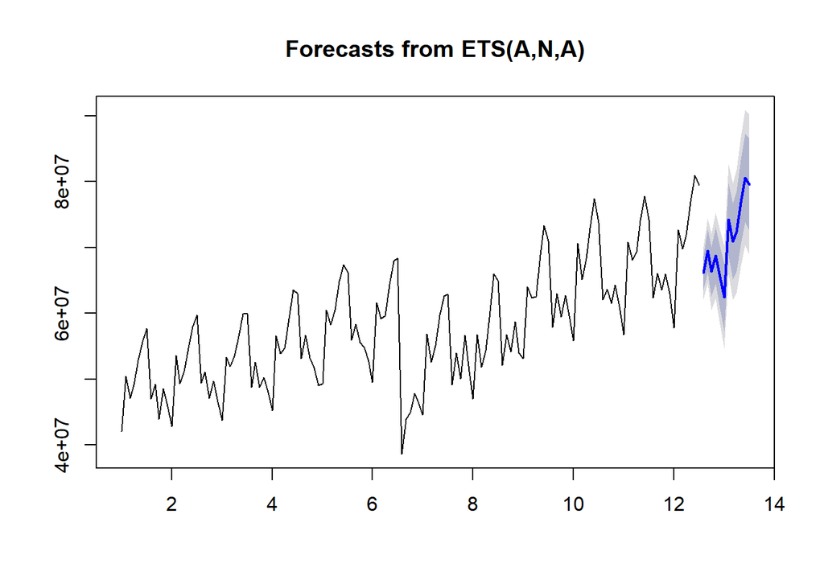

```r
#ETS AUTO
EST.Model3 <- ets(train.df)
forecast.Model3 <- forecast(EST.Model3,12)
acc.Model3 <-accuracy(forecast.Model3,test.df[1:12])
plot(forecast.Model3)
```

### 2.4 EST Model MMM

Our next EST model MMM was created using Multiplicative for the season, trend, and random. It is difficult to determine from the figure below for any changes from the previous model’s graph. Looking at the metrics will definitely give us some sense.

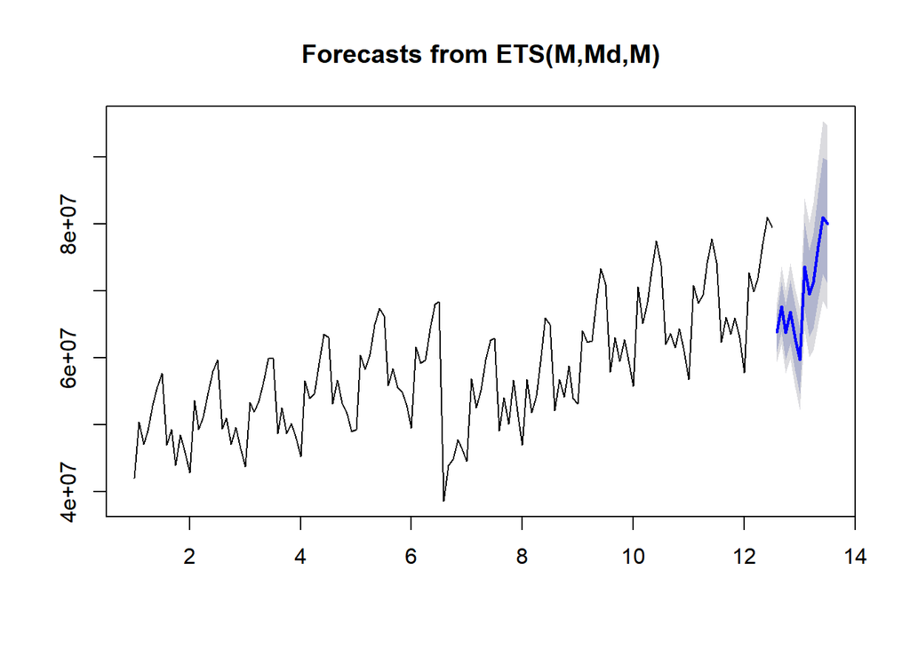

```r
#ETS MMM
EST.Model4 <- ets(train.df,model="MMM")
forecast.Model4 <- forecast(EST.Model4,12)
acc.Model4 <-accuracy(forecast.Model4,test.df[1:12])
plot(forecast.Model4)
```